# Incarceration in America

Emily Nakaone

2022-11-01

## Introduction

Mass incarceration has existed since slavery within the United States, and has yet to show any sign of slowing down. The reason for this unusual rate of incarceration has to do with the continued oppression and discrimination against minorities and the unfair criminalization of them. Through this report I seek to address the root of the problem and create visualizations to better communicate the urgency of this issue. Those who are being or have been incarcerated are direct stakeholders to this report as they have been directly impacted by mass incarceration and are burdened with the permanent record that can have a great impact on their overall quality of life. On the other hand, younger children and future generations are potential indirect stakeholders to this. This is because those who have been incarcerated often have a difficult time adjusting back to their lives and this may impact their ability to get a well paying job or seek higher education. If they choose to have children this will impact them as they may not be able to pay for their child’s education and provide a stable and comfortable life for them. From this I will seek to address values such as equality and justice through questions like what does the demographic of the incarcerated look like? And how has the trend in incarceration changed over the years?

## Growth of the U.S. Prison Population

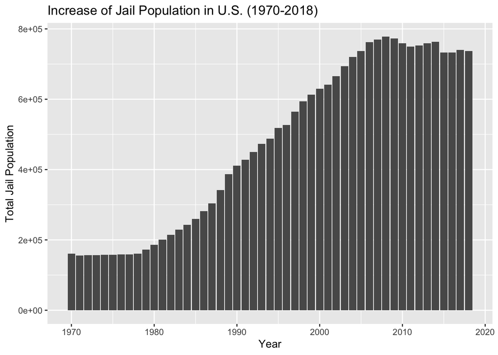

## Growth of Prison Population by State